# Statistical Inference Course Project

Han Yunxi

16 January 2015

## Investigation of Exponential Distribution in R vs Central Limit Theorem

This report investigates the distribution of averages of 40 numbers sampled from the exponential distribution with lambda = 0.2 .

The exponential distribution can be simulated in R with rexp(n, lambda) where lambda is the rate parameter. The mean of exponential distribution is 1/lambda and the standard deviation is also 1/lambda. We set lambda = 0.2 for all of the simulations.

Assumptions are:

```r
  set.seed(1)

  lambda <- 0.2      # Rate parameter
  mean <- 1/ lambda
  sd <- 1 / lambda   # Standard deviation

  sample_size <- 40
```

### Simulated Results

Let’s first look at the shape of the exponential function

[figure not shown]

```r
  shape <- rexp(sample_size * 1000 , rate = lambda)
  hist(shape, prob = TRUE, breaks = 20,
       main = "Histogram of 40 random numbers drawn from the exponential distribution",
       xlab ="Expected Value")
```

Now, let’s do 1000 simulations of 40 randomly selected exponential functions

```r
  # 1000 simulations of 40 random sample size
  xbar <- rep(0,1000)
  for (i in 1:1000) { xbar[i] <- mean (rexp(sample_size, rate = lambda))}
```

The distribution of the sample population means is then seen to be following a Normal distribution as follows:

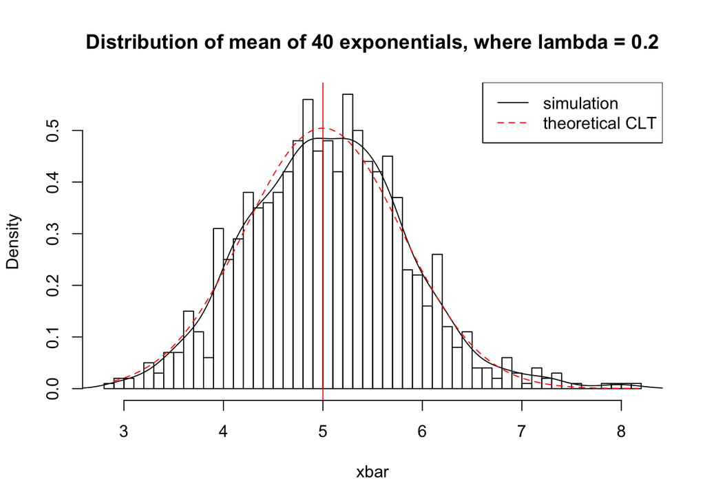

### Results

For the theoretical CLT, the mean and standard deviations of exponential distribution are given as 1/lambda. Hence the expected results are mean ,$\mu$ = 5 and variance, $\sigma^2 / n = 1/(\lambda^2 n)$ = 0.625

### Conclusion

However, as CLT gives no guarantee that sample size ($n$) is large enough, we run more simulations (1000) to ensure that the Law of Large Numbers requirement is met.

$\frac{\bar X_n - \mu}{\sigma / \sqrt{n}}= \frac{\sqrt n (\bar X_n - \mu)}{\sigma} = \frac{\mbox{Estimate} - \mbox{Mean of estimate}}{\mbox{Std. Err. of estimate}}$ has a distribution like that of a standard normal for large $n$